# Project 2

How do we measure a country’s place in the world? Economists, political scientists, and sociologists alike have set up countless metrics that allow us to compare nations with one another - rating coutries based on social, governmental, and economic factors. Such statistics are important in understanding modern geopolitics, but in the abstract, many of these statistics appear to exist in a vaccum. It is difficult to imagine how one could get a complete picture of a country’s place in the world by looking at their annual income per capita, their national CO2 emission levels, or their “democracy score.” The question remains - are statistics pertaining to different measures of national success related to one another? Is there any correlation between how well a country does in one area, and how they perform in another - seemingly unrelated - area? This project seeks to take a stab at answering this question, by comparing national statistics in a variety of fields - economic , environmental, health care, corruption/freedom indexes - to determine whether having information on some aspect of a country can truly allow us to assume their place in other areas.

Data is pulled largely from gapminder.org, a website which aggregates a wide variety of country-related indicators. Variables such as income per capita, gender disparities in education, and child mortality rates are collected for each of the world’s 192 countries over the course of the last several decades. This project compiles these statistics into one large data table, and seeks to use visualizations to examine how well they correlate.

The first step in collecting the data for this report was to alter each data frame to make joining them possible. Each of the data tables on gapminder.org had columns for each of the years studied, and rows for each of the 192 countries of the world. The “gather” function is a simple way to alter this setup - it creates a single “year” column, and repeats the names of each country for each year being studied, allowing each table to instead consist of just 3 columns - country, year, and the indicator being studied.

##Combining Datasets

After the data sets are altered, they must be combined using the “join” function.

###Pre-Combination Plots (Warmups) Just some warm-up plots comparing the data before the data tables have been combined. I will likely exclude these from the final draft.

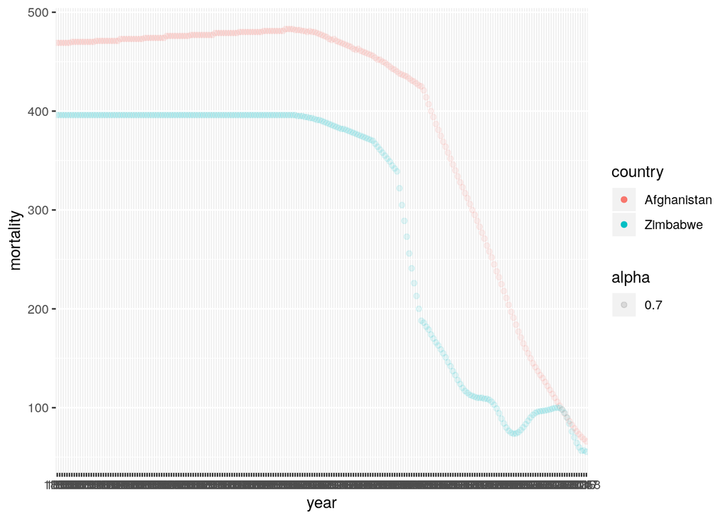

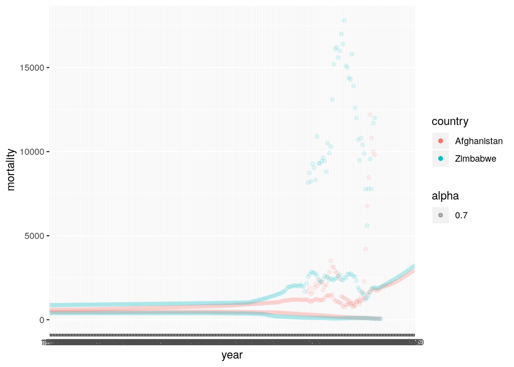

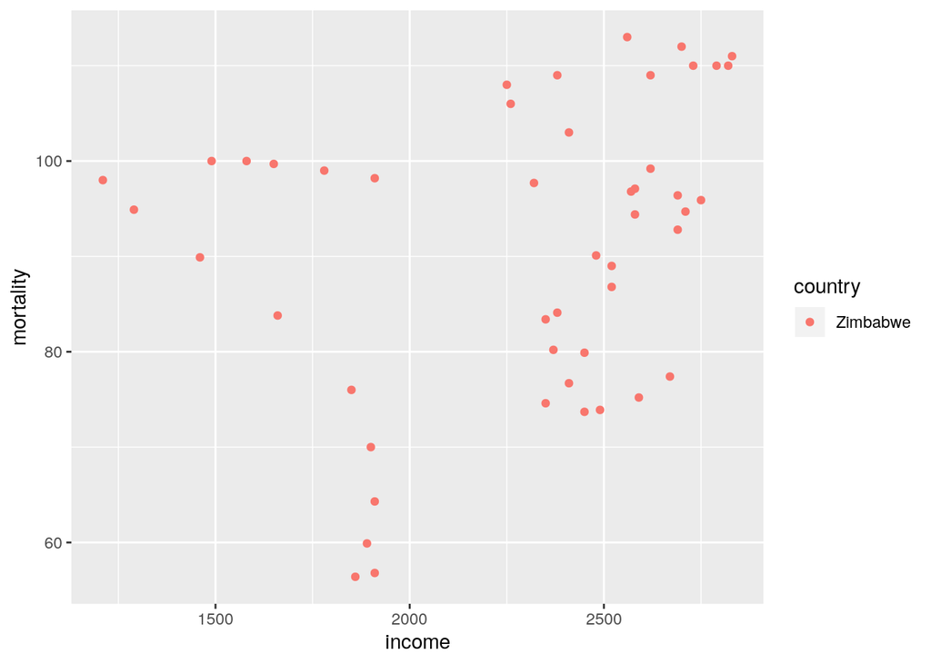

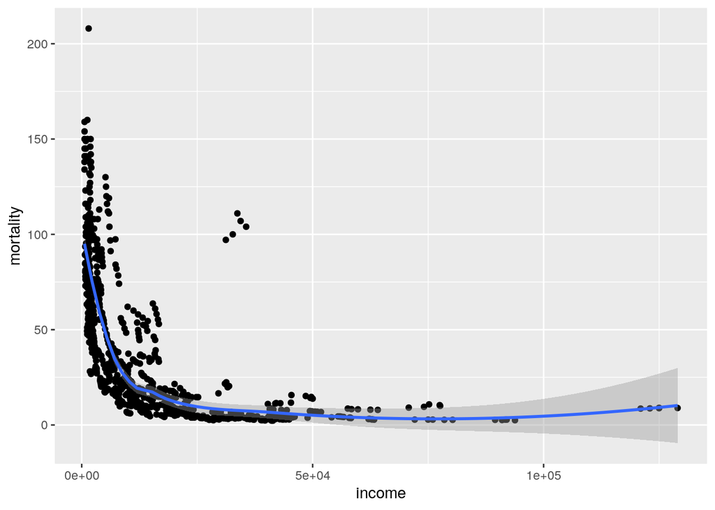

```
##    country              year               income          region
##  Length:8304        Length:8304        Min.   :   247   Length:8304
##  Class :character   Class :character   1st Qu.:  2388   Class :character
##  Mode  :character   Mode  :character   Median :  7240   Mode  :character
##                                        Mean   : 13684
##                                        3rd Qu.: 17900
##                                        Max.   :178000
##
##   northsouth          mortality        emissions
##  Length:8304        Min.   :  2.08   Min.   :       4
##  Class :character   1st Qu.: 15.90   1st Qu.:    1050
##  Mode  :character   Median : 42.60   Median :    7720
##                     Mean   : 71.56   Mean   :  122286
##                     3rd Qu.:105.00   3rd Qu.:   55500
##                     Max.   :399.00   Max.   :10300000
##                     NA's   :88       NA's   :989
##  ratio_of_girls_to_boys_in_primary_school democracyscore
##  Min.   :0.053                            Min.   :-10.0000
##  1st Qu.:0.887                            1st Qu.: -7.0000
##  Median :0.989                            Median :  1.0000
##  Mean   :0.924                            Mean   :  0.7555
##  3rd Qu.:1.020                            3rd Qu.:  8.0000
##  Max.   :1.470                            Max.   : 10.0000
##  NA's   :3668                             NA's   :2391
##        us           incomelevels
##  Min.   :0.00000   Min.   :0.000
##  1st Qu.:0.00000   1st Qu.:2.000
##  Median :0.00000   Median :3.000
##  Mean   :0.00578   Mean   :2.347
##  3rd Qu.:0.00000   3rd Qu.:3.000
##  Max.   :1.00000   Max.   :3.000
##
```

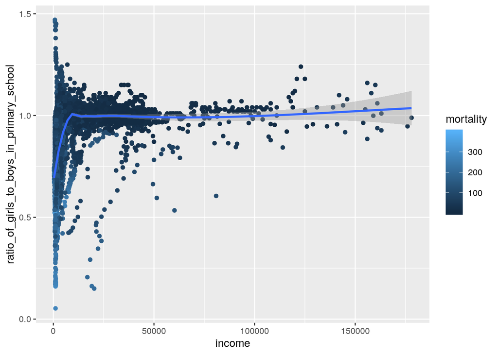

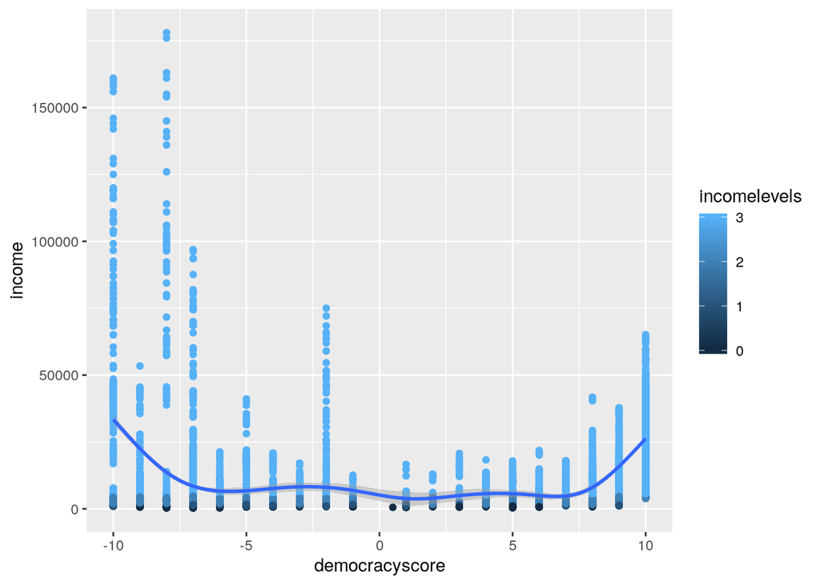

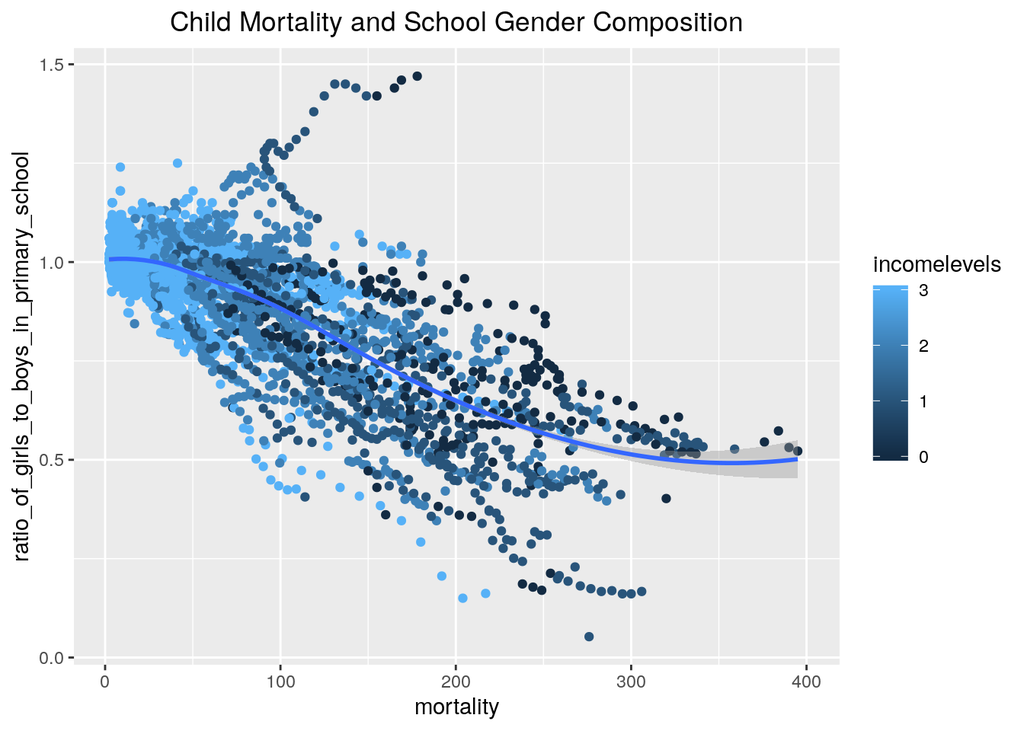

###Graph 1: Child Mortality, School Gender Composition, and Income

This graph displays child mortality levels as they relate to the ratio of girls to boys in primary and secondary education. A loess line is fitted onto these points, and indicates that as child mortality rates increase, so does the disparity between the number of girls and boys in school (there are higher numbers of boys relative to girls). The colors show the income levels of each of the countries studied, and indicate that nations with higher income levels per capita have lower child mortality rates, and a more even ratio of boys to girls in school.

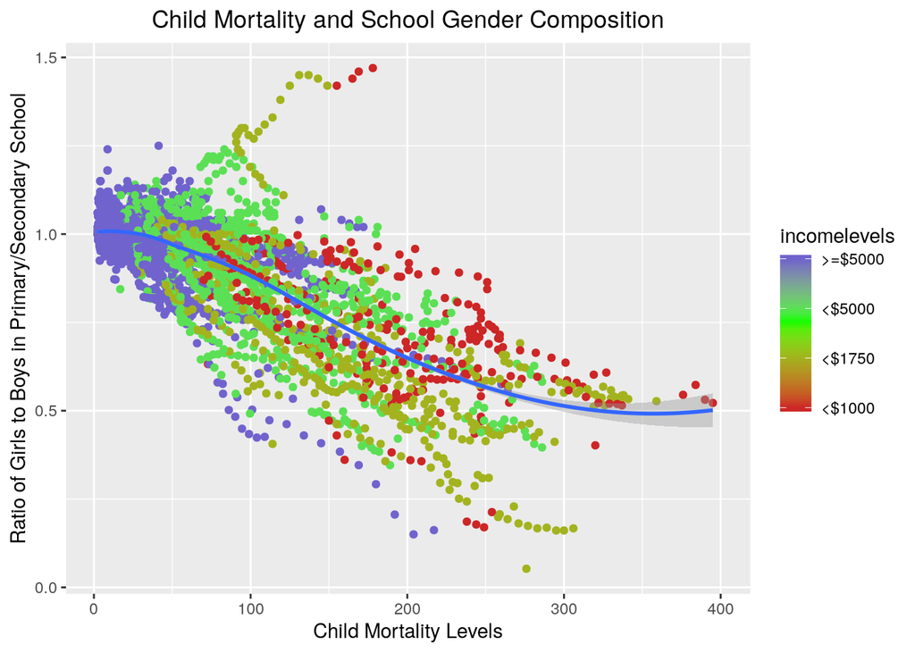

This graph also displays the comparison between child mortality and school gender composition, but this time the colors indicate the region of the world that each country is located in, as an attempt to parse out potential regional differences. An alpha value was used in one of the plots to give the points some transparency, in an attempt to make them easier to see. It appears that countries in Asia and the Arab States have the largest gender disparities in their schools, and that countries in Europe and North America have the lowest gender disparities - as well as relatively low levels of child mortality. The global north seems to perform better than the global south in each of these metrics.

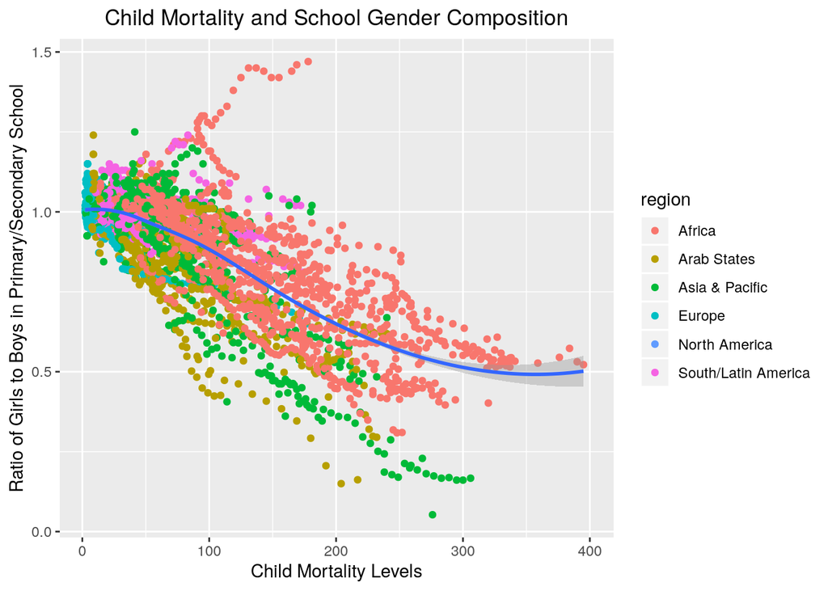

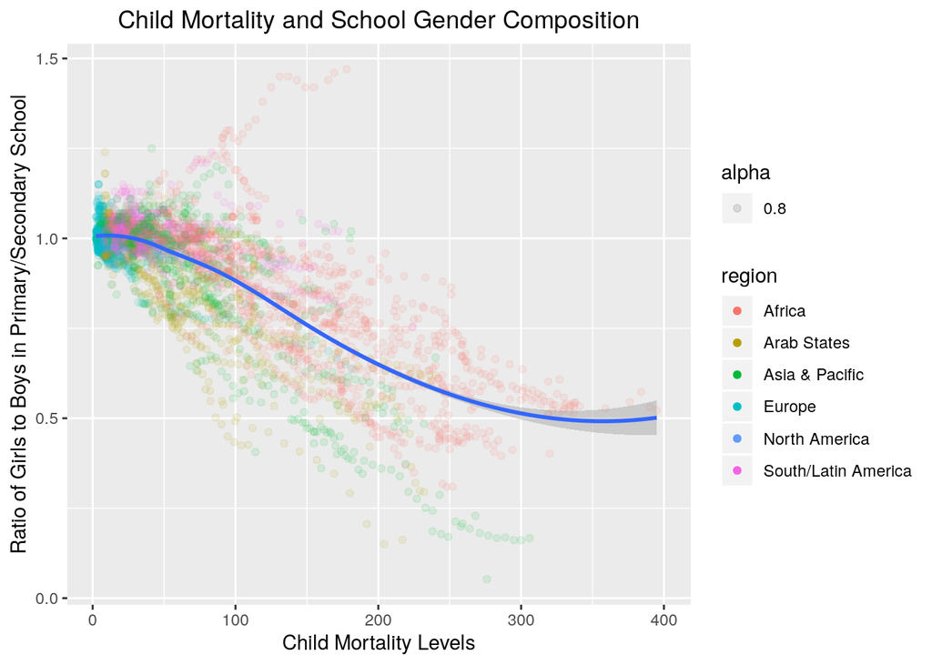

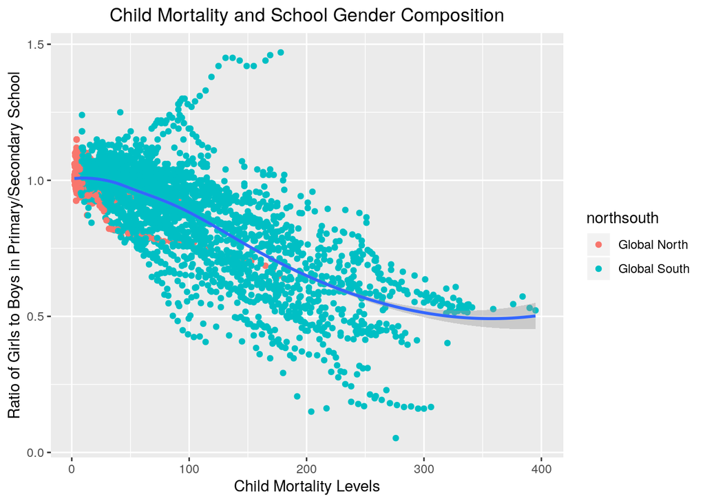

This graph examines income as it relates to school gender composition.

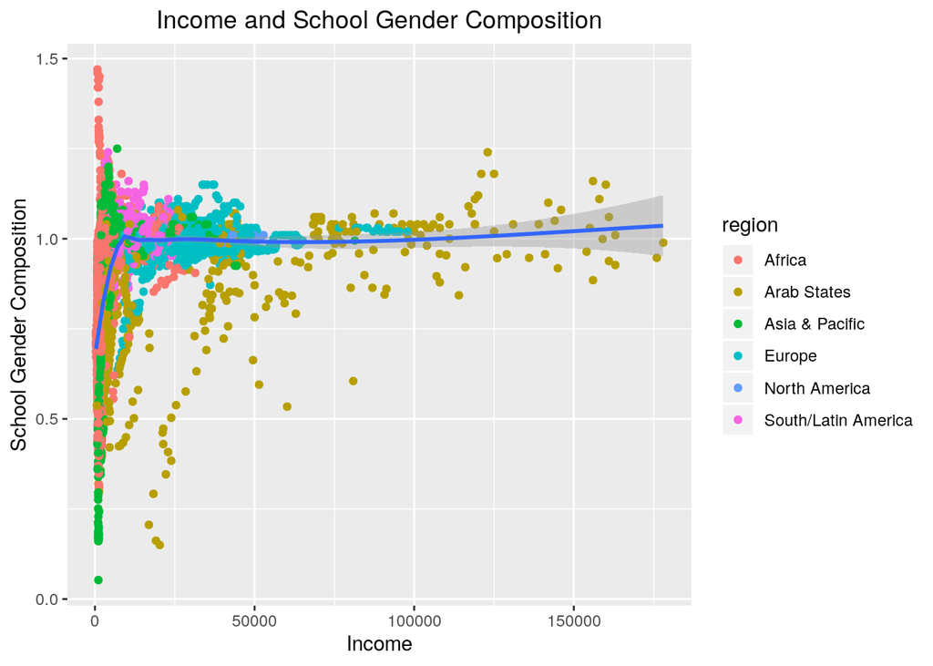

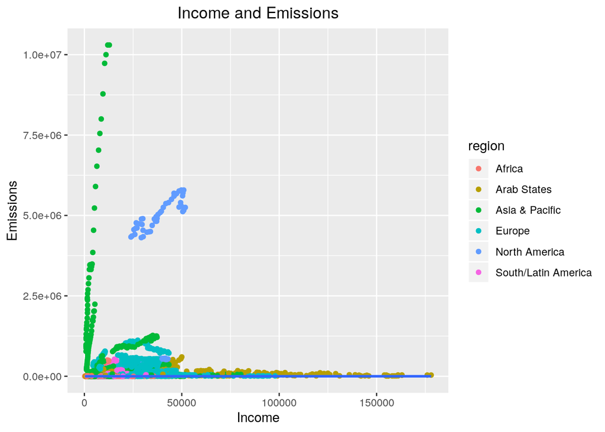

```
##
## Call:
## lm(formula = income ~ emissions, data = incomechildemissionsgenderdemocracy2)
##
## Residuals:
##    Min     1Q Median     3Q    Max
## -41572 -10519  -6089   3631 165093
##
## Coefficients:
##              Estimate Std. Error t value Pr(>|t|)
## (Intercept) 1.276e+04  2.125e+02   60.04   <2e-16 ***
## emissions   3.962e-03  3.751e-04   10.56   <2e-16 ***
## ---
## Signif. codes:  0 '***' 0.001 '**' 0.01 '*' 0.05 '.' 0.1 ' ' 1
##
## Residual standard error: 17750 on 7313 degrees of freedom
##   (989 observations deleted due to missingness)
## Multiple R-squared:  0.01503,    Adjusted R-squared:  0.01489
## F-statistic: 111.6 on 1 and 7313 DF,  p-value: < 2.2e-16
```

These graphs compare a country’s development scores with their corruption scores. There appears to be a clear correlation between the two - nations that are more developed appear to be less corrupt. However, it is also worth noting that these are very Westernized metrics of national success and may not be the best indicators of a country’s overall wellbeing.

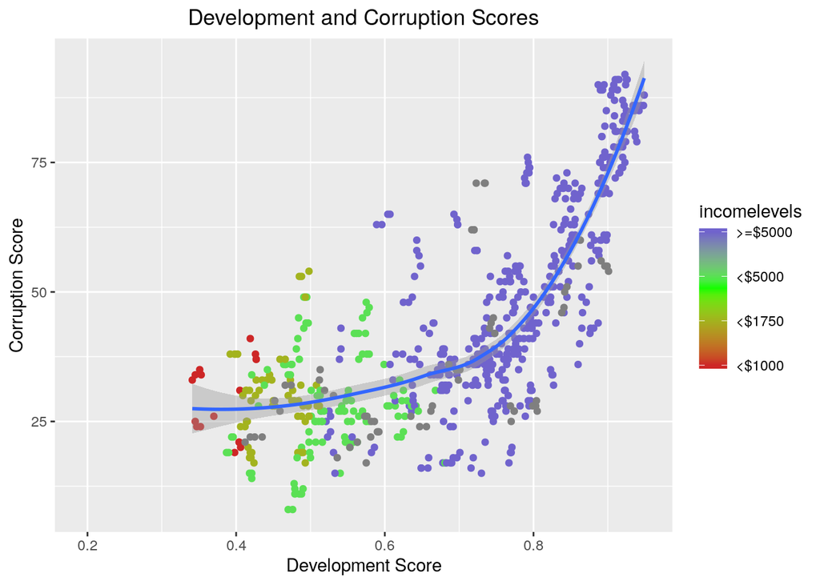

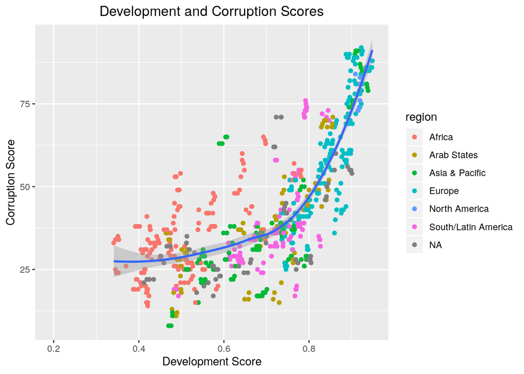

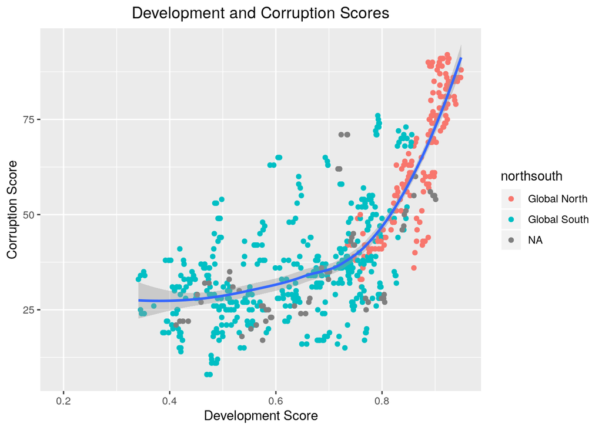

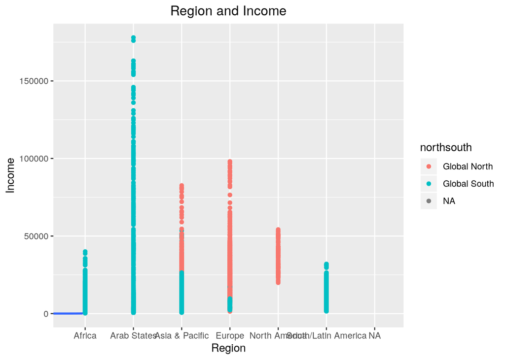